# Alcohol drinking

# 1 Description of DataSchema variable

The description of harmonised variables is the following:

- Short name: `current_oh`
- Variable label: `Current alcohol drinker`
- Variable description: `Current alcohol drinker`
- Domain: `Lifestyle and health behaviours`
- Value type: `categorical`
- Category coding:

| **Code** | **Category Label** |
| --- | --- |
| 0 | No |
| 1 | Yes |

- Category missings:

| **Code** | **Category Label** |
| --- | --- |
| 991 | CAPI/interviewer error |
| 992 | Impute |
| 993 | Disable to measure |
| 994 | Not attempt/not done |
| 995 | Does not answer |
| 996 | Not applicable |
| 997 | Refuse |
| 998 | Do not know |
| 999 | Missing |

- Short name: `freq_oh`
- Variable label: `Frequency of alcohol drinking`
- Variable description: `Frequency of alcohol drinking`
- Domain: `Lifestyle and health behaviours`
- Value type: `categorical`
- Category coding:

| **Code** | **Category Label** |
| --- | --- |
| 0 | never |
| 1 | rare |
| 2 | often |

- Category missings:

| **Code** | **Category Label** |
| --- | --- |
| 991 | CAPI/interviewer error |
| 992 | Impute |
| 993 | Disable to measure |
| 994 | Not attempt/not done |
| 995 | Does not answer |
| 996 | Not applicable |
| 997 | Refuse |
| 998 | Do not know |
| 999 | Missing |

- Short name: `past_oh`
- Variable label: `Past drinking`
- Variable description: `Did you drink in the past?`
- Domain: `Lifestyle and health behaviours`
- Value type: `categorical`
- Category coding:

| **Code** | **Category Label** |
| --- | --- |
| 0 | No |
| 1 | Yes |

- Category missings:

| **Code** | **Category Label** |
| --- | --- |
| 991 | CAPI/interviewer error |
| 992 | Impute |
| 993 | Disable to measure |
| 994 | Not attempt/not done |
| 995 | Does not answer |
| 996 | Not applicable |
| 997 | Refuse |
| 998 | Do not know |
| 999 | Missing |

# 2 Data process

## 2.1 Cuba

### 2.1.1 Wave 1

#### 2.1.1.1 Study-specific variable description

| **Name** | `PALCNOW` | `PALCPAST` |
| --- | --- | --- |
| **Label** | `alcohol - units drunk per week now` `1 unit = a small glass of beer = a single measure of spirits = 1 glass of wine or sherry` `32 units = 1 bottle of spirits` | `alcohol - units drunk per week before age of 65 years` `1 unit = a small glass of beer = a single measure of spirits = 1 glass of wine or sherry` `32 units = 1 bottle of spirits` |
| **Table name** | `1066-Cuba-Baseline` | `1066-Cuba-Baseline` |
| **Categories** | `continuous` | `continuous` |
| **Missings** | `NA` | `NA` |
| **Description** |  |  |

PALCNOW

| Sample size | Missing values |
| --- | --- |
| 2813 | 47 |

Summary

| Min. | 1st Qu. | Median | Mean | 3rd Qu. | Max. | NA’s |
| --- | --- | --- | --- | --- | --- | --- |
| 0 | 0 | 0 | 2.164 | 0 | 324 | 47 |

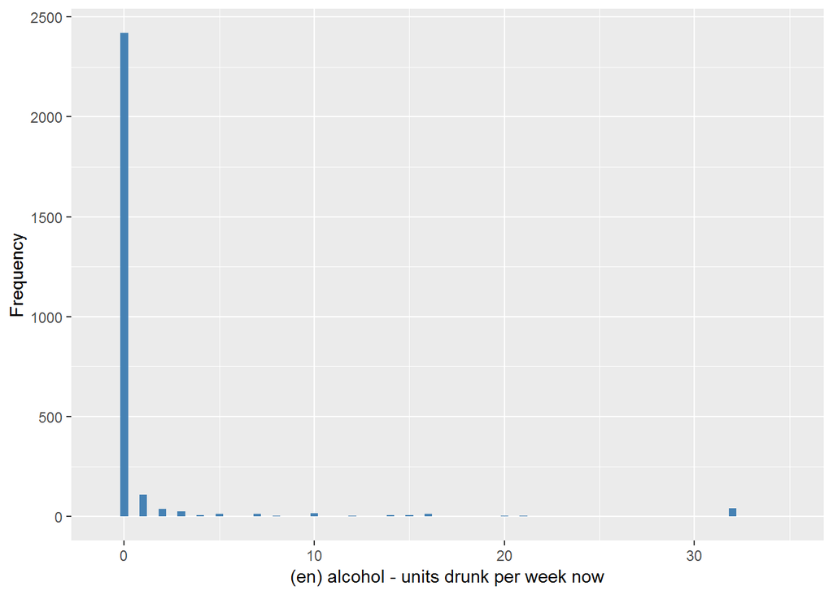

PALCPAST

| Sample size | Missing values |
| --- | --- |
| 2813 | 41 |

Summary

| Min. | 1st Qu. | Median | Mean | 3rd Qu. | Max. | NA’s |
| --- | --- | --- | --- | --- | --- | --- |
| 0 | 0 | 0 | 6.609 | 0 | 400 | 41 |

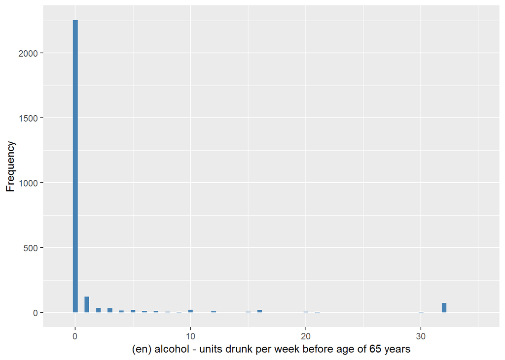

#### 2.1.1.2 Harmonisation algorithm

To compute `current_oh` from the study-specific variable it has to be recoded as follows:

- `PALCNOW == 0 into 0`
- `PALCNOW > 0 into 1`
- `NA into 999`

To compute `freq_oh` from the study-specific variable it has to be recoded as follows:

- `If PALCNOW=0 then 'drinking_frequency'=0`
- `if PALCNOW=1 or 2 then 'drinking_frequency'=1`
- `if PALCNOW>2 then 'drinking_frequency'=2`

To compute `past_oh` from the study-specific variable it has to be recoded as follows:

- `PALCPAST == 0 into 0`
- `PALCPAST > 0 into 1`
- `NA into 999`

**R script:**

```r
t1066_ds_cuba_w1 <- tibble(id = t1066_cuba_w1$id)
t1066_ds_cuba_w1$freq_oh <- car::recode(t1066_cuba_w1$PALCNOW, "0 = 0; c(1,2) = 1; 3:hi = 2; NA = 999")
t1066_ds_cuba_w1$current_oh <- car::recode(t1066_ds_cuba_w1$freq_oh, "2 = 1")
t1066_ds_cuba_w1$past_oh <- car::recode(t1066_cuba_w1$PALCPAST, "0 = 0; 1:hi = 1; NA = 999")
```

#### 2.1.1.3 Statistics of the new harmonized variable

Current alcohol drinker

| Sample size | Missing values |
| --- | --- |
| 2813 | 47 |

Category

|  | 0 | 1 |
| --- | --- | --- |
| Frequency | 2419.00 | 347.00 |
| Percentage | 85.99 | 12.34 |

Type of missing

|  | 991 | 992 | 993 | 994 | 995 | 996 | 997 | 998 | 999 | NA |
| --- | --- | --- | --- | --- | --- | --- | --- | --- | --- | --- |
| Frequency | 0 | 0 | 0 | 0 | 0 | 0 | 0 | 0 | 47.00 | 0 |
| Percentage | 0 | 0 | 0 | 0 | 0 | 0 | 0 | 0 | 1.67 | 0 |

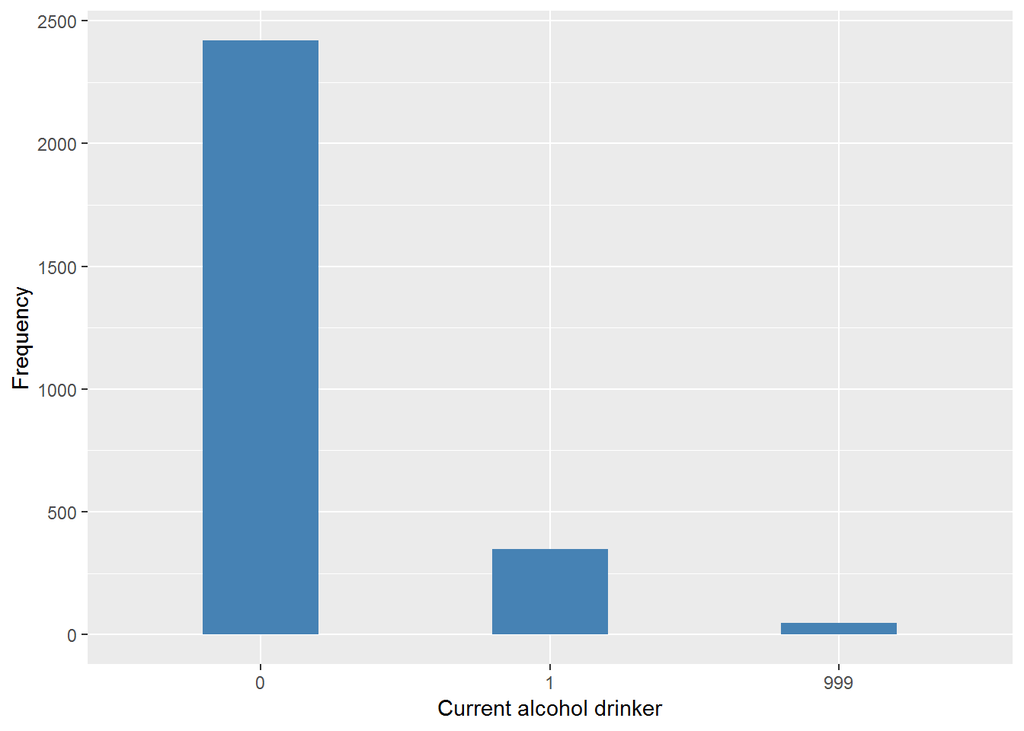

Frequency of alcohol drinking

| Sample size | Missing values |
| --- | --- |
| 2813 | 47 |

Category

|  | 0 | 1 | 2 |
| --- | --- | --- | --- |
| Frequency | 2419.00 | 146.00 | 201.00 |
| Percentage | 85.99 | 5.19 | 7.15 |

Type of missing

|  | 991 | 992 | 993 | 994 | 995 | 996 | 997 | 998 | 999 | NA |
| --- | --- | --- | --- | --- | --- | --- | --- | --- | --- | --- |
| Frequency | 0 | 0 | 0 | 0 | 0 | 0 | 0 | 0 | 47.00 | 0 |
| Percentage | 0 | 0 | 0 | 0 | 0 | 0 | 0 | 0 | 1.67 | 0 |

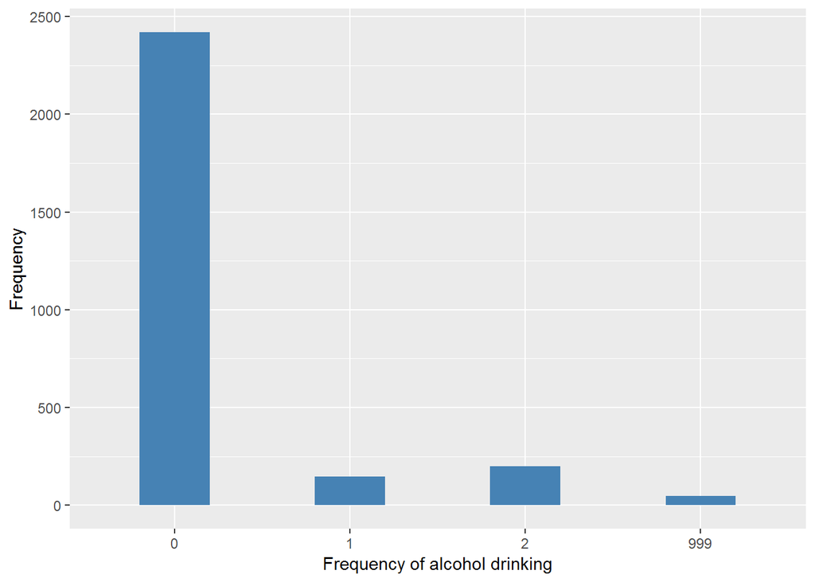

Past drinking

| Sample size | Missing values |
| --- | --- |
| 2813 | 41 |

Category

|  | 0 | 1 |
| --- | --- | --- |
| Frequency | 2255.00 | 517.00 |
| Percentage | 80.16 | 18.38 |

Type of missing

|  | 991 | 992 | 993 | 994 | 995 | 996 | 997 | 998 | 999 | NA |
| --- | --- | --- | --- | --- | --- | --- | --- | --- | --- | --- |
| Frequency | 0 | 0 | 0 | 0 | 0 | 0 | 0 | 0 | 41.00 | 0 |
| Percentage | 0 | 0 | 0 | 0 | 0 | 0 | 0 | 0 | 1.46 | 0 |

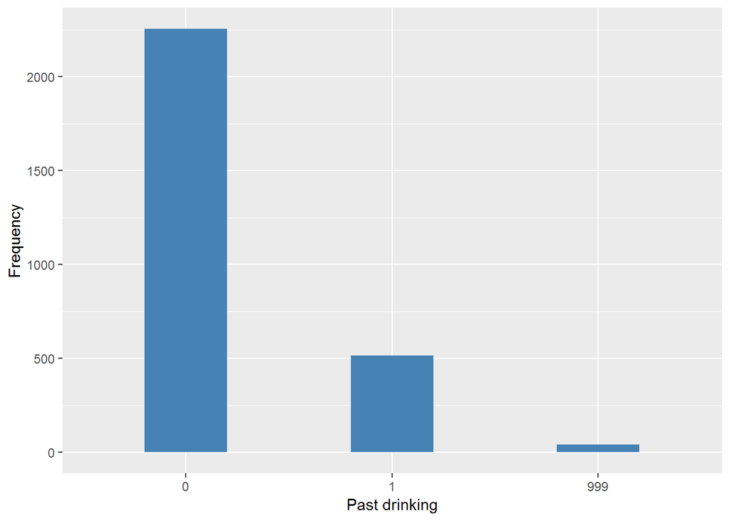

#### 2.1.1.4 Validation

### 2.1.2 Wave 2

#### 2.1.2.1 Study-specific variable description

| **Name** | `f_PALCPAST` |
| --- | --- |
| **Label** | `In the last week how much did you drink` `1 unit = a small glass of beer = a single measure of spirits = 1 glass of wine or sherry` `32 units = 1 bottle of spirits` |
| **Table name** | `1066-Cuba-Followup` |
| **Categories** | `continuous` |
| **Missings** | `NA` |
| **Description** |  |

f_PALCPAST

| Sample size | Missing values |
| --- | --- |
| 2007 | 35 |

Summary

| Min. | 1st Qu. | Median | Mean | 3rd Qu. | Max. | NA’s |
| --- | --- | --- | --- | --- | --- | --- |
| 0 | 0 | 0 | 0.4057 | 0 | 96 | 35 |

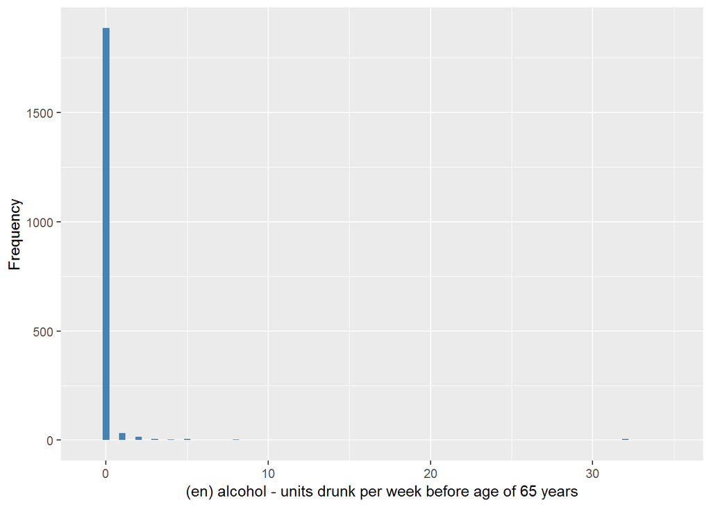

#### 2.1.2.2 Harmonisation algorithm

To compute `current_oh` from the study-specific variable it has to be recoded as follows:

- `f_PALCPAST == 0 into 0`
- `f_PALCPAST > 0 into 1`
- `NA into 999`

To compute `freq_oh` from the study-specific variable it has to be recoded as follows:

- `If f_PALCPAST=0 then 'drinking_frequency'=0`
- `if f_PALCPAST=1 or 2 then 'drinking_frequency'=1`
- `if f_PALCPAST>2 then 'drinking_frequency'=2`

To compute `past_oh` from the study-specific variable it has to be recoded as follows:

- `take from wave 1`

**R script:**

```r
t1066_ds_cuba_w2 <- tibble(id = t1066_cuba_w2$id)

t1066_ds_cuba_w2$freq_oh <- car::recode(t1066_cuba_w2$f_PALCPAST, "0 = 0; c(1,2) = 1; 3:hi = 2; NA = 999")
t1066_ds_cuba_w2$current_oh <- car::recode(t1066_ds_cuba_w2$freq_oh, "2 = 1")

t1066_cuba_w2 <- left_join(t1066_cuba_w2, t1066_ds_cuba_w1, by = "id")
t1066_ds_cuba_w2$past_oh <- t1066_cuba_w2$past_oh
```

#### 2.1.2.3 Statistics of the new harmonized variable

Current alcohol drinker

| Sample size | Missing values |
| --- | --- |
| 2007 | 35 |

Category

|  | 0 | 1 |
| --- | --- | --- |
| Frequency | 1886.00 | 86.00 |
| Percentage | 93.97 | 4.29 |

Type of missing

|  | 991 | 992 | 993 | 994 | 995 | 996 | 997 | 998 | 999 | NA |
| --- | --- | --- | --- | --- | --- | --- | --- | --- | --- | --- |
| Frequency | 0 | 0 | 0 | 0 | 0 | 0 | 0 | 0 | 35.00 | 0 |
| Percentage | 0 | 0 | 0 | 0 | 0 | 0 | 0 | 0 | 1.74 | 0 |

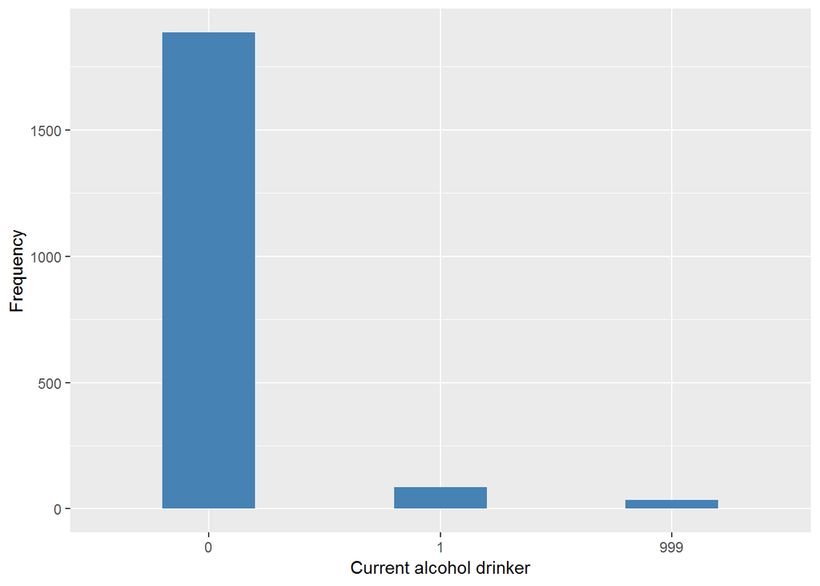

Frequency of alcohol drinking

| Sample size | Missing values |
| --- | --- |
| 2007 | 35 |

Category

|  | 0 | 1 | 2 |
| --- | --- | --- | --- |
| Frequency | 1886.00 | 48.00 | 38.00 |
| Percentage | 93.97 | 2.39 | 1.89 |

Type of missing

|  | 991 | 992 | 993 | 994 | 995 | 996 | 997 | 998 | 999 | NA |
| --- | --- | --- | --- | --- | --- | --- | --- | --- | --- | --- |
| Frequency | 0 | 0 | 0 | 0 | 0 | 0 | 0 | 0 | 35.00 | 0 |
| Percentage | 0 | 0 | 0 | 0 | 0 | 0 | 0 | 0 | 1.74 | 0 |

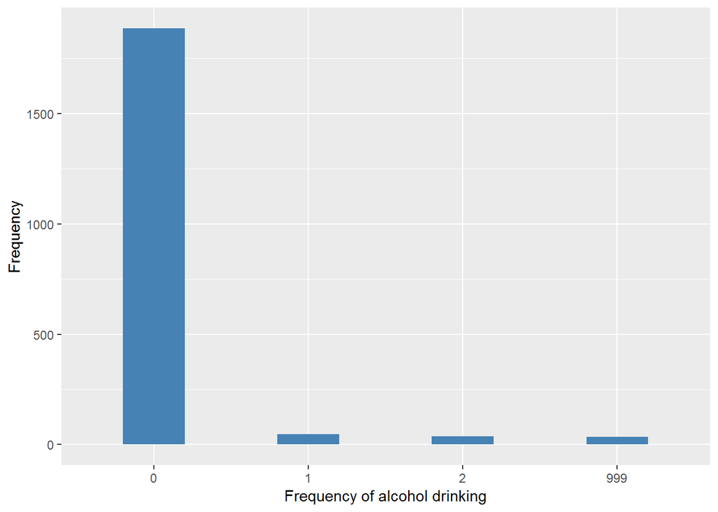

Past drinking

| Sample size | Missing values |
| --- | --- |
| 2007 | 25 |

Category

|  | 0 | 1 |
| --- | --- | --- |
| Frequency | 1624.00 | 358.00 |
| Percentage | 80.92 | 17.84 |

Type of missing

|  | 991 | 992 | 993 | 994 | 995 | 996 | 997 | 998 | 999 | NA |
| --- | --- | --- | --- | --- | --- | --- | --- | --- | --- | --- |
| Frequency | 0 | 0 | 0 | 0 | 0 | 0 | 0 | 0 | 25.00 | 0 |
| Percentage | 0 | 0 | 0 | 0 | 0 | 0 | 0 | 0 | 1.25 | 0 |

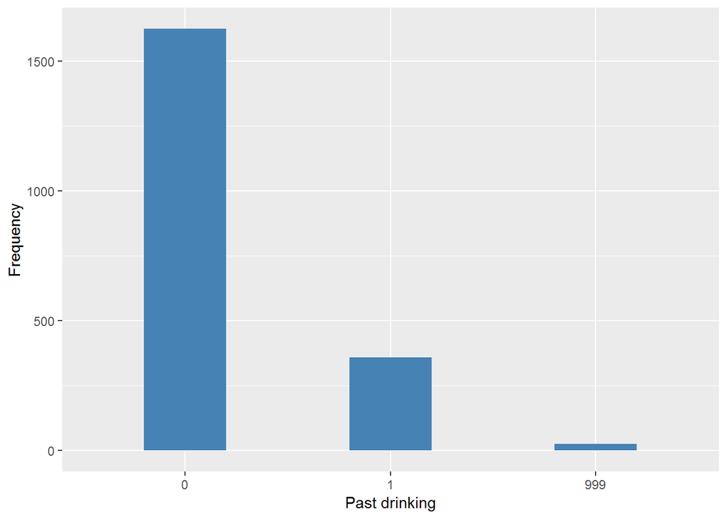

#### 2.1.2.4 Validation

## 2.2 India

### 2.2.1 Wave 1

#### 2.2.1.1 Study-specific variable description

| **Name** | `PALCNOW` | `PALCPAST` |
| --- | --- | --- |
| **Label** | `alcohol - units drunk per week now` `1 unit = a small glass of beer = a single measure of spirits = 1 glass of wine or sherry` `32 units = 1 bottle of spirits` | `alcohol - units drunk per week before age of 65 years` `1 unit = a small glass of beer = a single measure of spirits = 1 glass of wine or sherry` `32 units = 1 bottle of spirits` |
| **Table name** | `1066-India-Baseline` | `1066-India-Baseline` |
| **Categories** | `continuous` | `continuous` |
| **Missings** | `NA` | `NA` |
| **Description** |  |  |

PALCNOW

| Sample size | Missing values |
| --- | --- |
| 2004 | 129 |

Summary

| Min. | 1st Qu. | Median | Mean | 3rd Qu. | Max. | NA’s |
| --- | --- | --- | --- | --- | --- | --- |
| 0 | 0 | 0 | 0.2384 | 0 | 32 | 129 |

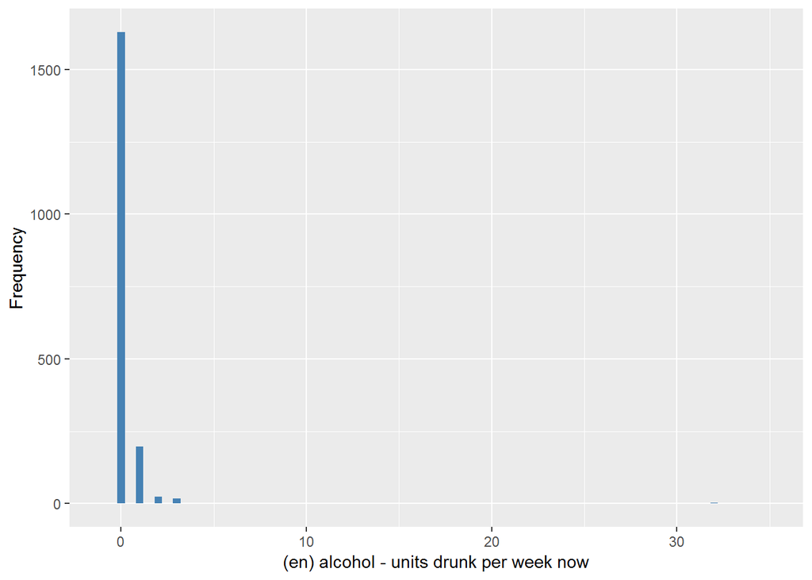

PALCPAST

| Sample size | Missing values |
| --- | --- |
| 2004 | 64 |

Summary

| Min. | 1st Qu. | Median | Mean | 3rd Qu. | Max. | NA’s |
| --- | --- | --- | --- | --- | --- | --- |
| 0 | 0 | 0 | 0.5119 | 0 | 99 | 64 |

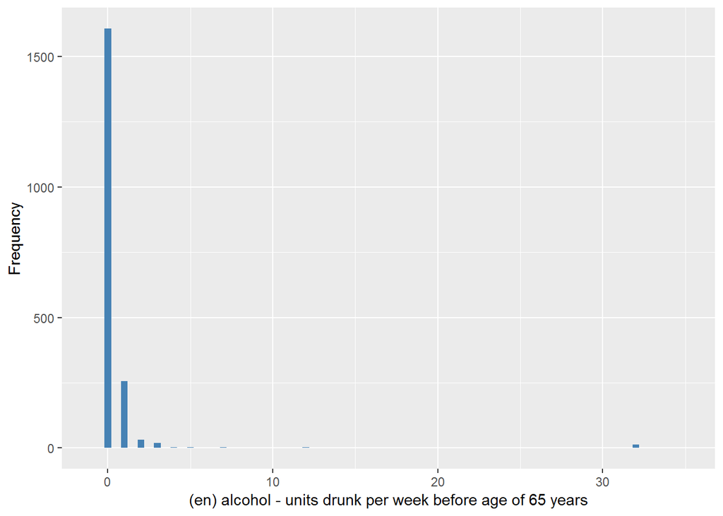

#### 2.2.1.2 Harmonisation algorithm

To compute `current_oh` from the study-specific variable it has to be recoded as follows:

- `PALCNOW == 0 into 0`
- `PALCNOW > 0 into 1`
- `NA into 999`

To compute `freq_oh` from the study-specific variable it has to be recoded as follows:

- `If PALCNOW=0 then 'drinking_frequency'=0`
- `if PALCNOW=1 or 2 then 'drinking_frequency'=1`
- `if PALCNOW>2 then 'drinking_frequency'=2`

To compute `past_oh` from the study-specific variable it has to be recoded as follows:

- `PALCPAST == 0 into 0`
- `PALCPAST > 0 into 1`
- `NA into 999`

**R script:**

```r
t1066_ds_india_w1 <- tibble(id = t1066_india_w1$id)
t1066_ds_india_w1$freq_oh <- car::recode(t1066_india_w1$PALCNOW, "0 = 0; c(1,2) = 1; 3:hi = 2; NA = 999")
t1066_ds_india_w1$current_oh <- car::recode(t1066_ds_india_w1$freq_oh, "2 = 1")
t1066_ds_india_w1$past_oh <- car::recode(t1066_india_w1$PALCPAST, "0 = 0; 1:hi = 1; NA = 999")
```

#### 2.2.1.3 Statistics of the new harmonized variable

Current alcohol drinker

| Sample size | Missing values |
| --- | --- |
| 2004 | 129 |

Category

|  | 0 | 1 |
| --- | --- | --- |
| Frequency | 1629.00 | 246.00 |
| Percentage | 81.29 | 12.28 |

Type of missing

|  | 991 | 992 | 993 | 994 | 995 | 996 | 997 | 998 | 999 | NA |
| --- | --- | --- | --- | --- | --- | --- | --- | --- | --- | --- |
| Frequency | 0 | 0 | 0 | 0 | 0 | 0 | 0 | 0 | 129.00 | 0 |
| Percentage | 0 | 0 | 0 | 0 | 0 | 0 | 0 | 0 | 6.44 | 0 |

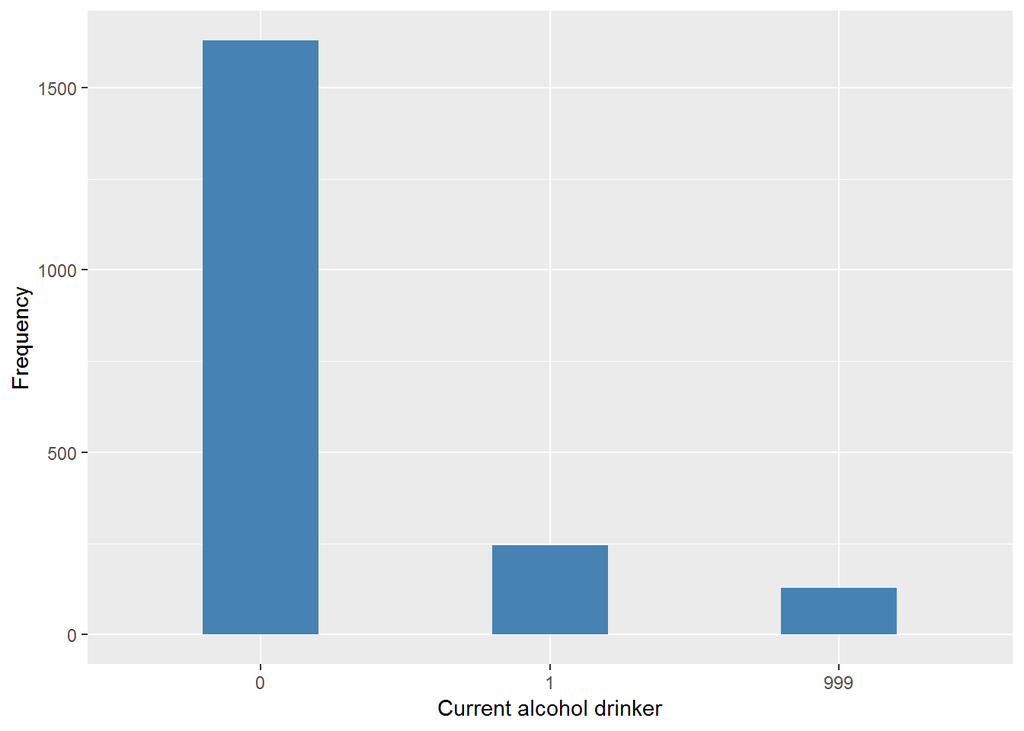

Frequency of alcohol drinking

| Sample size | Missing values |
| --- | --- |
| 2004 | 129 |

Category

|  | 0 | 1 | 2 |
| --- | --- | --- | --- |
| Frequency | 1629.00 | 222.00 | 24.0 |
| Percentage | 81.29 | 11.08 | 1.2 |

Type of missing

|  | 991 | 992 | 993 | 994 | 995 | 996 | 997 | 998 | 999 | NA |
| --- | --- | --- | --- | --- | --- | --- | --- | --- | --- | --- |
| Frequency | 0 | 0 | 0 | 0 | 0 | 0 | 0 | 0 | 129.00 | 0 |
| Percentage | 0 | 0 | 0 | 0 | 0 | 0 | 0 | 0 | 6.44 | 0 |

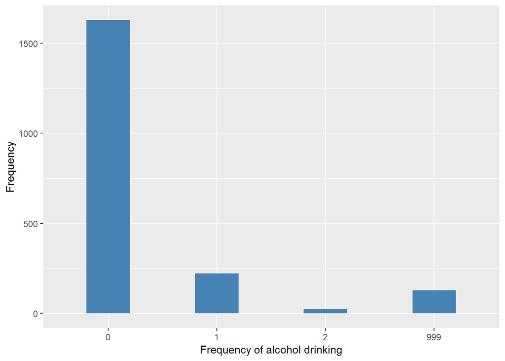

Past drinking

| Sample size | Missing values |
| --- | --- |
| 2004 | 64 |

Category

|  | 0 | 1 |
| --- | --- | --- |
| Frequency | 1607.00 | 333.00 |
| Percentage | 80.19 | 16.62 |

Type of missing

|  | 991 | 992 | 993 | 994 | 995 | 996 | 997 | 998 | 999 | NA |
| --- | --- | --- | --- | --- | --- | --- | --- | --- | --- | --- |
| Frequency | 0 | 0 | 0 | 0 | 0 | 0 | 0 | 0 | 64.00 | 0 |
| Percentage | 0 | 0 | 0 | 0 | 0 | 0 | 0 | 0 | 3.19 | 0 |

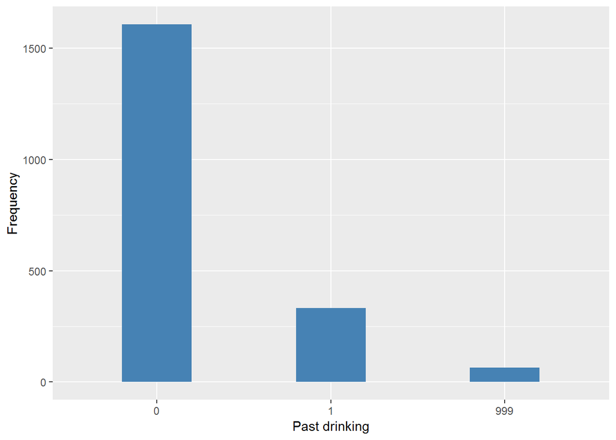

#### 2.2.1.4 Validation

## 2.3 Urban China

### 2.3.1 Wave 1

#### 2.3.1.1 Study-specific variable description

| **Name** | `PALCNOW` | `PALCPAST` |
| --- | --- | --- |
| **Label** | `alcohol - units drunk per week now` `1 unit = a small glass of beer = a single measure of spirits = 1 glass of wine or sherry` `32 units = 1 bottle of spirits` | `alcohol - units drunk per week before age of 65 years` `1 unit = a small glass of beer = a single measure of spirits = 1 glass of wine or sherry` `32 units = 1 bottle of spirits` |
| **Table name** | `1066-UrbanChina-Baseline` | `1066-UrbanChina-Baseline` |
| **Categories** | `continuous` | `continuous` |
| **Description** |  |  |

PALCNOW

| Sample size | Missing values |
| --- | --- |
| 1160 | 0 |

Summary

| Min. | 1st Qu. | Median | Mean | 3rd Qu. | Max. |
| --- | --- | --- | --- | --- | --- |
| 0 | 0 | 0 | 1.136 | 0 | 210 |

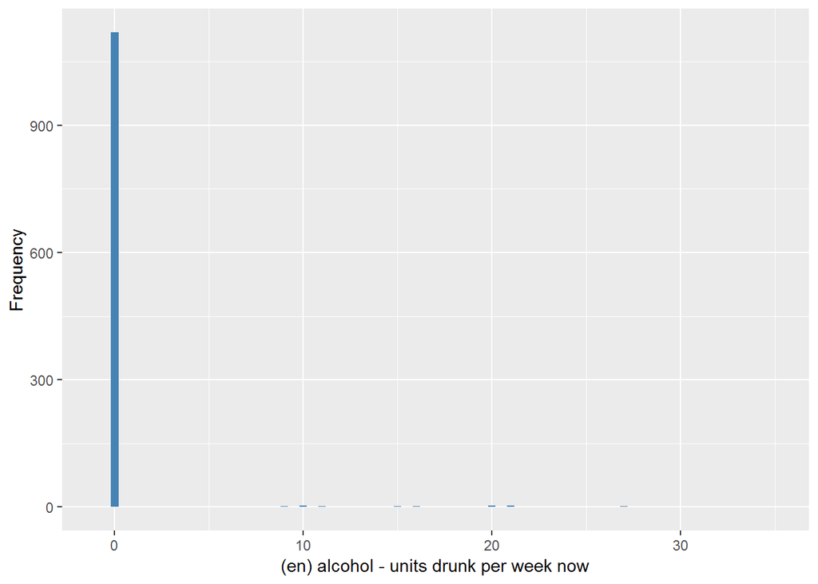

PALCPAST

| Sample size | Missing values |
| --- | --- |
| 1160 | 0 |

Summary

| Min. | 1st Qu. | Median | Mean | 3rd Qu. | Max. |
| --- | --- | --- | --- | --- | --- |
| 0 | 0 | 0 | 1.903 | 0 | 400 |

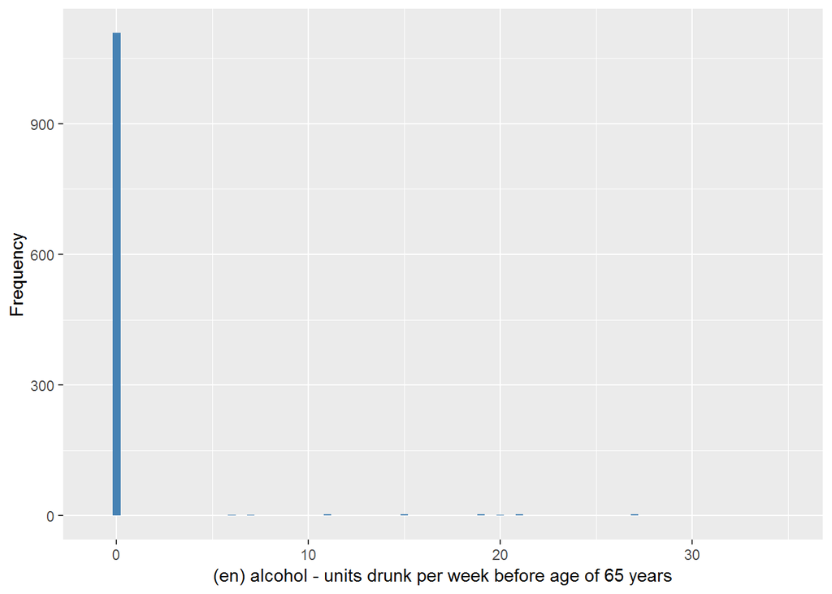

#### 2.3.1.2 Harmonisation algorithm

To compute `current_oh` from the study-specific variable it has to be recoded as follows:

- `PALCNOW == 0 into 0`
- `PALCNOW > 0 into 1`
- `NA into 999`

To compute `freq_oh` from the study-specific variable it has to be recoded as follows:

- `If PALCNOW=0 then 'drinking_frequency'=0`
- `if PALCNOW=1 or 2 then 'drinking_frequency'=1`
- `if PALCNOW>2 then 'drinking_frequency'=2`

To compute `past_oh` from the study-specific variable it has to be recoded as follows:

- `PALCPAST == 0 into 0`
- `PALCPAST > 0 into 1`
- `NA into 999`

**R script:**

```r
t1066_ds_UCh_w1 <- tibble(id = t1066_UCh_w1$id)
t1066_ds_UCh_w1$freq_oh <- car::recode(t1066_UCh_w1$PALCNOW, "0 = 0; c(1,2) = 1; 3:hi = 2; NA = 999")
t1066_ds_UCh_w1$current_oh <- car::recode(t1066_ds_UCh_w1$freq_oh, "2 = 1")
t1066_ds_UCh_w1$past_oh <- car::recode(t1066_UCh_w1$PALCPAST, "0 = 0; 1:hi = 1; NA = 999")
```

#### 2.3.1.3 Statistics of the new harmonized variable

Current alcohol drinker

| Sample size | Missing values |
| --- | --- |
| 1160 | 0 |

Category

|  | 0 | 1 |
| --- | --- | --- |
| Frequency | 1119.00 | 41.00 |
| Percentage | 96.47 | 3.53 |

Type of missing

|  | 991 | 992 | 993 | 994 | 995 | 996 | 997 | 998 | 999 | NA |
| --- | --- | --- | --- | --- | --- | --- | --- | --- | --- | --- |
| Frequency | 0 | 0 | 0 | 0 | 0 | 0 | 0 | 0 | 0 | 0 |
| Percentage | 0 | 0 | 0 | 0 | 0 | 0 | 0 | 0 | 0 | 0 |

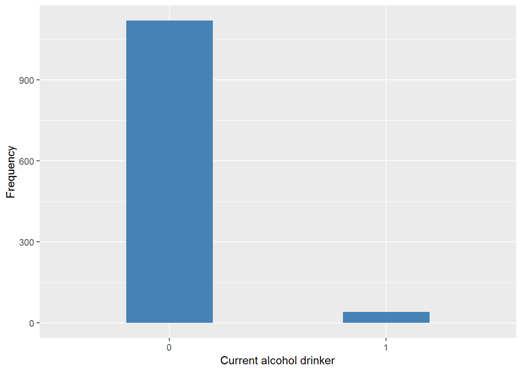

Frequency of alcohol drinking

| Sample size | Missing values |
| --- | --- |
| 1160 | 0 |

Category

|  | 0 | 2 |
| --- | --- | --- |
| Frequency | 1119.00 | 41.00 |
| Percentage | 96.47 | 3.53 |

Type of missing

|  | 991 | 992 | 993 | 994 | 995 | 996 | 997 | 998 | 999 | NA |
| --- | --- | --- | --- | --- | --- | --- | --- | --- | --- | --- |
| Frequency | 0 | 0 | 0 | 0 | 0 | 0 | 0 | 0 | 0 | 0 |
| Percentage | 0 | 0 | 0 | 0 | 0 | 0 | 0 | 0 | 0 | 0 |

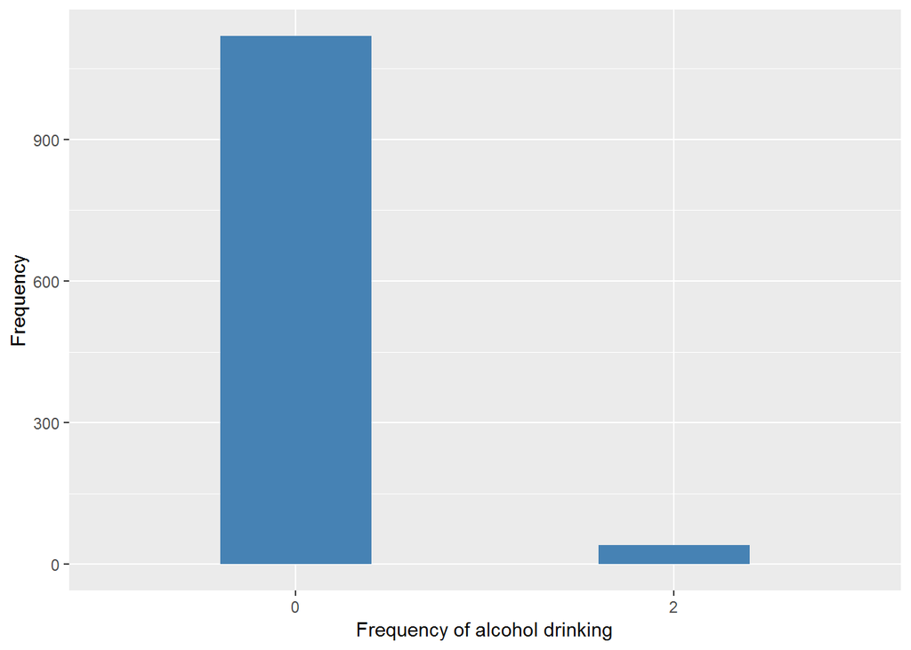

Past drinking

| Sample size | Missing values |
| --- | --- |
| 1160 | 0 |

Category

|  | 0 | 1 |
| --- | --- | --- |
| Frequency | 1108.00 | 52.00 |
| Percentage | 95.52 | 4.48 |

Type of missing

|  | 991 | 992 | 993 | 994 | 995 | 996 | 997 | 998 | 999 | NA |
| --- | --- | --- | --- | --- | --- | --- | --- | --- | --- | --- |
| Frequency | 0 | 0 | 0 | 0 | 0 | 0 | 0 | 0 | 0 | 0 |
| Percentage | 0 | 0 | 0 | 0 | 0 | 0 | 0 | 0 | 0 | 0 |

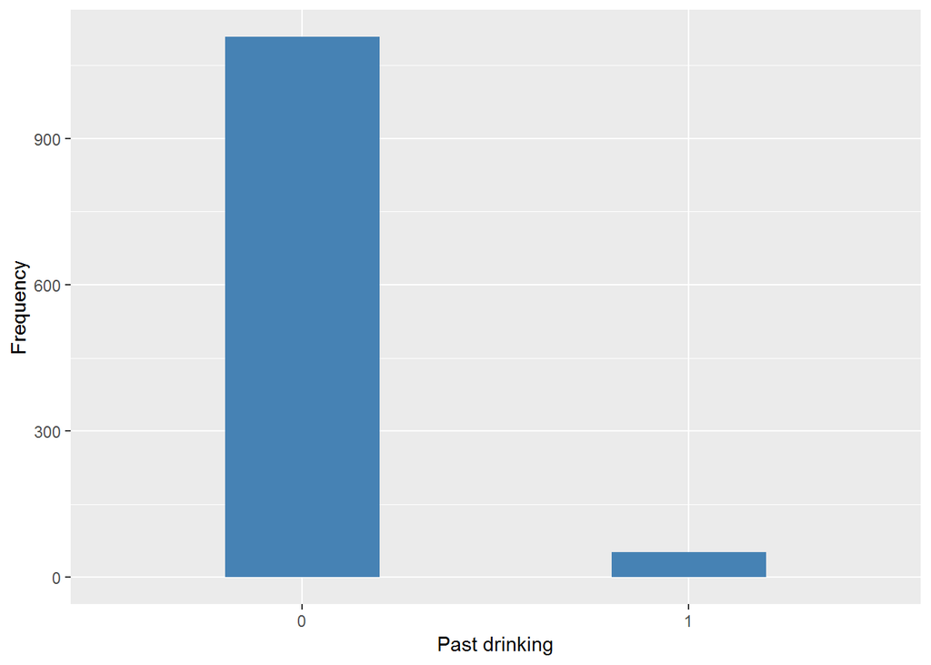

#### 2.3.1.4 Validation

### 2.3.2 Wave 2

#### 2.3.2.1 Study-specific variable description

| **Name** | `f_PALCPAST` |
| --- | --- |
| **Label** | `In the last week how much did you drink` `1 unit = a small glass of beer = a single measure of spirits = 1 glass of wine or sherry` `32 units = 1 bottle of spirits` |
| **Table name** | `1066-UrbanChina-Followup` |
| **Categories** | `continuous` |
| **Missings** | `NA` |
| **Description** |  |

f_PALCPAST

| Sample size | Missing values |
| --- | --- |
| 741 | 0 |

Summary

| Min. | 1st Qu. | Median | Mean | 3rd Qu. | Max. |
| --- | --- | --- | --- | --- | --- |
| 0 | 0 | 0 | 2.301 | 0 | 221 |

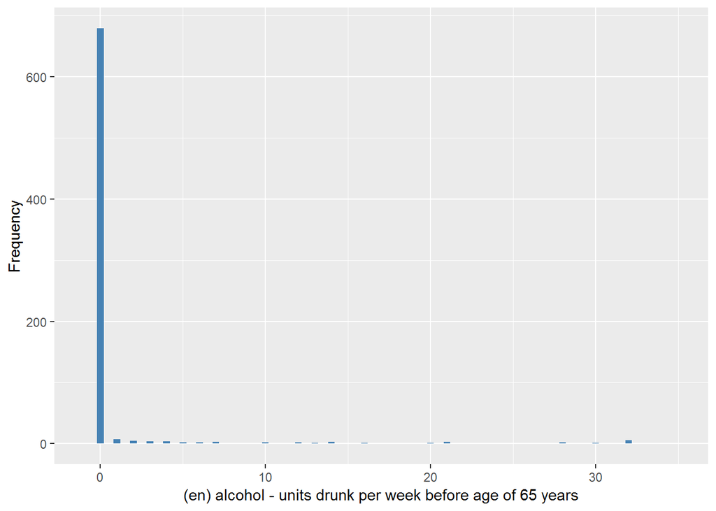

#### 2.3.2.2 Harmonisation algorithm

To compute `current_oh` from the study-specific variable it has to be recoded as follows:

- `f_PALCPAST == 0 into 0`
- `f_PALCPAST > 0 into 1`
- `NA into 999`

To compute `freq_oh` from the study-specific variable it has to be recoded as follows:

- `If f_PALCPAST=0 then 'drinking_frequency'=0`
- `if f_PALCPAST=1 or 2 then 'drinking_frequency'=1`
- `if f_PALCPAST>2 then 'drinking_frequency'=2`

To compute `past_oh` from the study-specific variable it has to be recoded as follows:

- `take from wave 1`

**R script:**

```r
t1066_ds_UCh_w2 <- tibble(id = t1066_UCh_w2$id)

t1066_ds_UCh_w2$freq_oh <- car::recode(t1066_UCh_w2$f_PALCPAST, "0 = 0; c(1,2) = 1; 3:hi = 2; NA = 999")
t1066_ds_UCh_w2$current_oh <- car::recode(t1066_ds_UCh_w2$freq_oh, "2 = 1")

t1066_UCh_w2 <- left_join(t1066_UCh_w2, t1066_ds_UCh_w1, by = "id")
t1066_ds_UCh_w2$past_oh <- t1066_UCh_w2$past_oh
```

#### 2.3.2.3 Statistics of the new harmonized variable

Current alcohol drinker

| Sample size | Missing values |
| --- | --- |
| 741 | 0 |

Category

|  | 0 | 1 |
| --- | --- | --- |
| Frequency | 679.00 | 62.00 |
| Percentage | 91.63 | 8.37 |

Type of missing

|  | 991 | 992 | 993 | 994 | 995 | 996 | 997 | 998 | 999 | NA |
| --- | --- | --- | --- | --- | --- | --- | --- | --- | --- | --- |
| Frequency | 0 | 0 | 0 | 0 | 0 | 0 | 0 | 0 | 0 | 0 |
| Percentage | 0 | 0 | 0 | 0 | 0 | 0 | 0 | 0 | 0 | 0 |

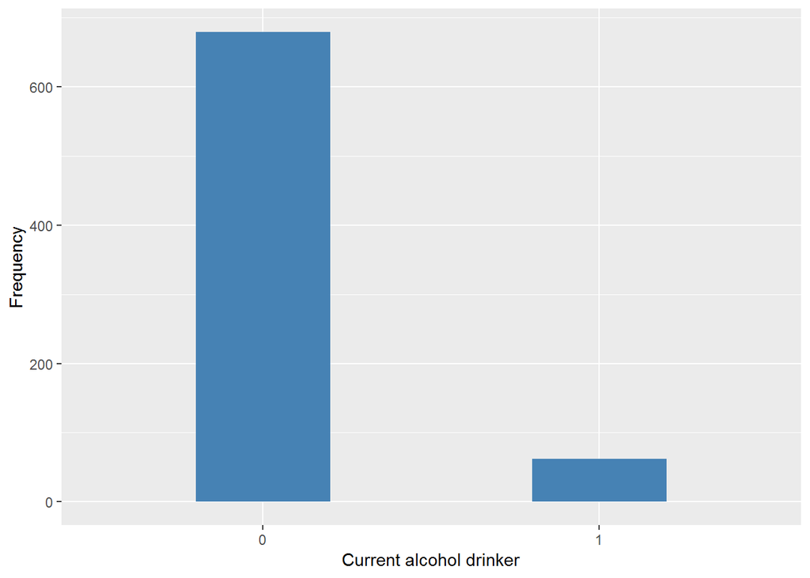

Frequency of alcohol drinking

| Sample size | Missing values |
| --- | --- |
| 741 | 0 |

Category

|  | 0 | 1 | 2 |
| --- | --- | --- | --- |
| Frequency | 679.00 | 12.00 | 50.00 |
| Percentage | 91.63 | 1.62 | 6.75 |

Type of missing

|  | 991 | 992 | 993 | 994 | 995 | 996 | 997 | 998 | 999 | NA |
| --- | --- | --- | --- | --- | --- | --- | --- | --- | --- | --- |
| Frequency | 0 | 0 | 0 | 0 | 0 | 0 | 0 | 0 | 0 | 0 |
| Percentage | 0 | 0 | 0 | 0 | 0 | 0 | 0 | 0 | 0 | 0 |

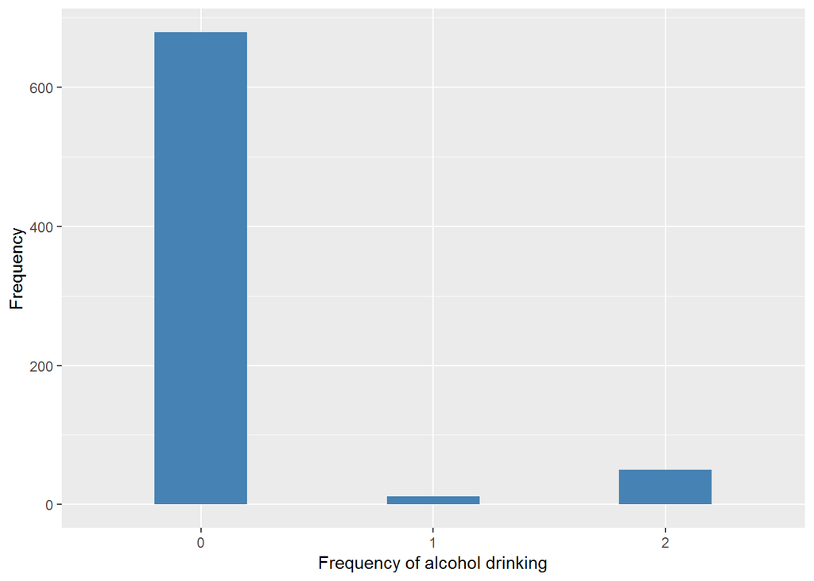

Past drinking

| Sample size | Missing values |
| --- | --- |
| 741 | 0 |

Category

|  | 0 | 1 |
| --- | --- | --- |
| Frequency | 710.00 | 31.00 |
| Percentage | 95.82 | 4.18 |

Type of missing

|  | 991 | 992 | 993 | 994 | 995 | 996 | 997 | 998 | 999 | NA |
| --- | --- | --- | --- | --- | --- | --- | --- | --- | --- | --- |
| Frequency | 0 | 0 | 0 | 0 | 0 | 0 | 0 | 0 | 0 | 0 |
| Percentage | 0 | 0 | 0 | 0 | 0 | 0 | 0 | 0 | 0 | 0 |

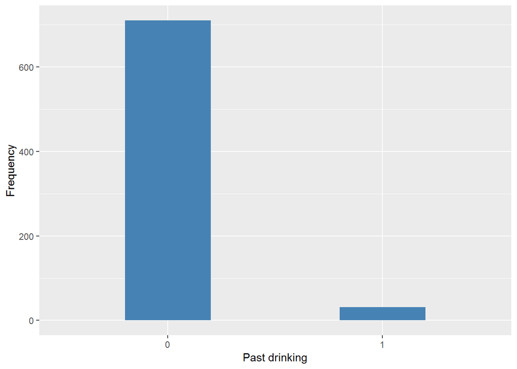

#### 2.3.2.4 Validation

## 2.4 Rural China

### 2.4.1 Wave 1

#### 2.4.1.1 Study-specific variable description

| **Name** | `PALCNOW` | `PALCPAST` |
| --- | --- | --- |
| **Label** | `alcohol - units drunk per week now` `1 unit = a small glass of beer = a single measure of spirits = 1 glass of wine or sherry` `32 units = 1 bottle of spirits` | `alcohol - units drunk per week before age of 65 years` `1 unit = a small glass of beer = a single measure of spirits = 1 glass of wine or sherry` `32 units = 1 bottle of spirits` |
| **Table name** | `1066-RuralChina-Baseline` | `1066-RuralChina-Baseline` |
| **Categories** | `continuous` | `continuous` |
| **Description** |  |  |

PALCNOW

| Sample size | Missing values |
| --- | --- |
| 1002 | 0 |

Summary

| Min. | 1st Qu. | Median | Mean | 3rd Qu. | Max. |
| --- | --- | --- | --- | --- | --- |
| 0 | 0 | 0 | 3.348 | 0 | 189 |

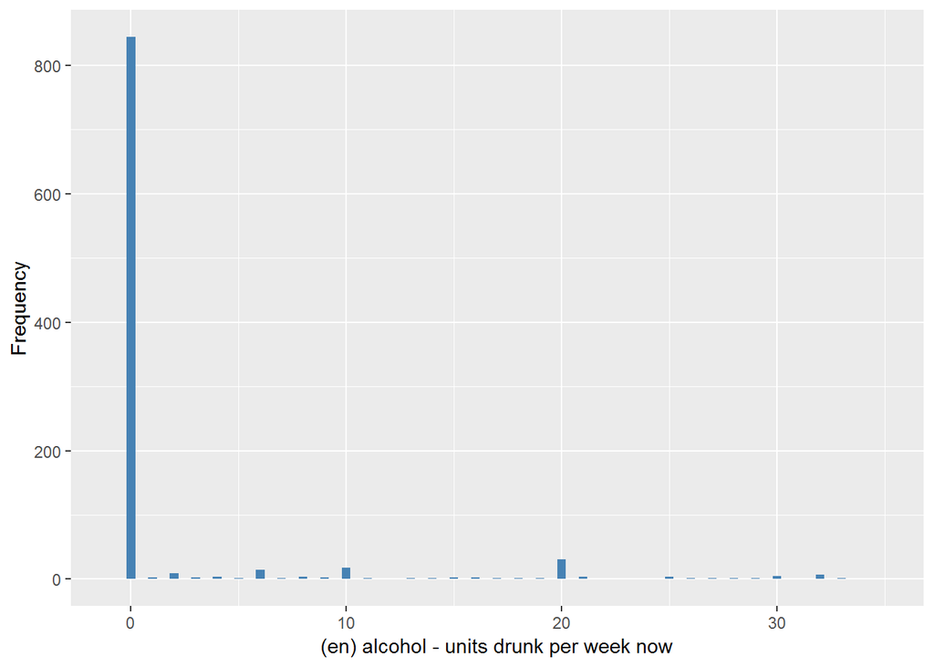

PALCPAST

| Sample size | Missing values |
| --- | --- |
| 1002 | 0 |

Summary

| Min. | 1st Qu. | Median | Mean | 3rd Qu. | Max. |
| --- | --- | --- | --- | --- | --- |
| 0 | 0 | 0 | 4.716 | 0 | 385 |

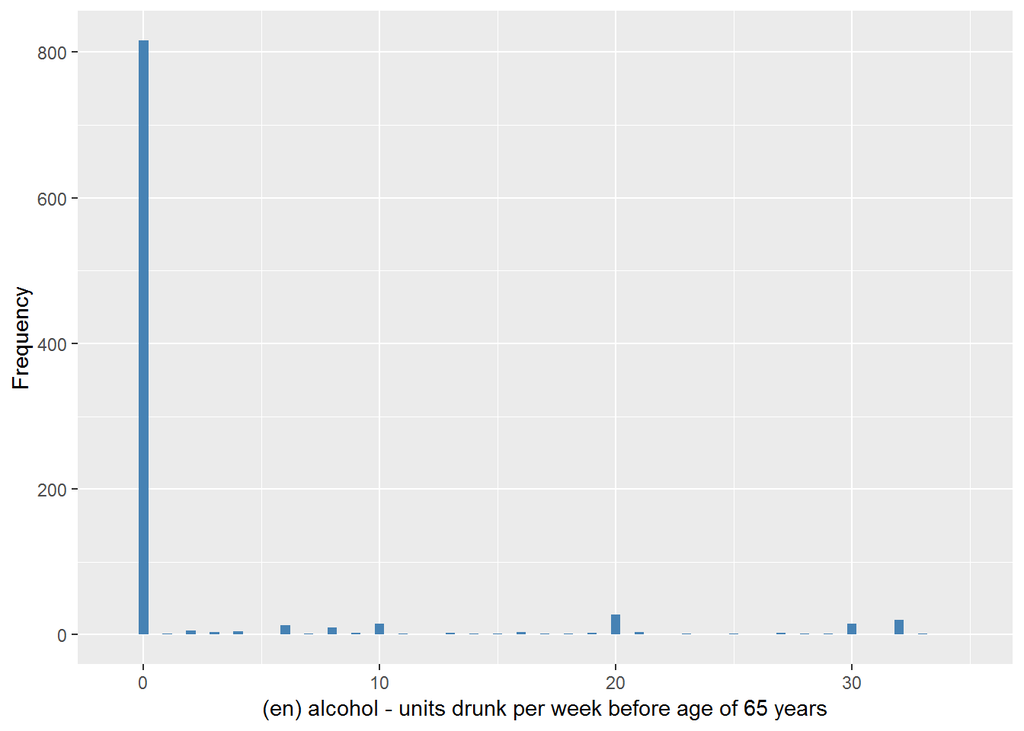

#### 2.4.1.2 Harmonisation algorithm

To compute `current_oh` from the study-specific variable it has to be recoded as follows:

- `PALCNOW == 0 into 0`
- `PALCNOW > 0 into 1`
- `NA into 999`

To compute `freq_oh` from the study-specific variable it has to be recoded as follows:

- `If PALCNOW=0 then 'drinking_frequency'=0`
- `if PALCNOW=1 or 2 then 'drinking_frequency'=1`
- `if PALCNOW>2 then 'drinking_frequency'=2`

To compute `past_oh` from the study-specific variable it has to be recoded as follows:

- `PALCPAST == 0 into 0`
- `PALCPAST > 0 into 1`
- `NA into 999`

**R script:**

```r
t1066_ds_RCh_w1 <- tibble(id = t1066_RCh_w1$id)
t1066_ds_RCh_w1$freq_oh <- car::recode(t1066_RCh_w1$PALCNOW, "0 = 0; c(1,2) = 1; 3:hi = 2; NA = 999")
t1066_ds_RCh_w1$current_oh <- car::recode(t1066_ds_RCh_w1$freq_oh, "2 = 1")
t1066_ds_RCh_w1$past_oh <- car::recode(t1066_RCh_w1$PALCPAST, "0 = 0; 1:hi = 1; NA = 999")
```

#### 2.4.1.3 Statistics of the new harmonized variable

Current alcohol drinker

| Sample size | Missing values |
| --- | --- |
| 1002 | 0 |

Category

|  | 0 | 1 |
| --- | --- | --- |
| Frequency | 844.00 | 158.00 |
| Percentage | 84.23 | 15.77 |

Type of missing

|  | 991 | 992 | 993 | 994 | 995 | 996 | 997 | 998 | 999 | NA |
| --- | --- | --- | --- | --- | --- | --- | --- | --- | --- | --- |
| Frequency | 0 | 0 | 0 | 0 | 0 | 0 | 0 | 0 | 0 | 0 |
| Percentage | 0 | 0 | 0 | 0 | 0 | 0 | 0 | 0 | 0 | 0 |

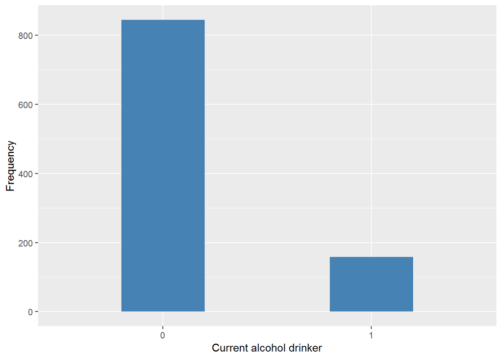

Frequency of alcohol drinking

| Sample size | Missing values |
| --- | --- |
| 1002 | 0 |

Category

|  | 0 | 1 | 2 |
| --- | --- | --- | --- |
| Frequency | 844.00 | 12.0 | 146.00 |
| Percentage | 84.23 | 1.2 | 14.57 |

Type of missing

|  | 991 | 992 | 993 | 994 | 995 | 996 | 997 | 998 | 999 | NA |
| --- | --- | --- | --- | --- | --- | --- | --- | --- | --- | --- |
| Frequency | 0 | 0 | 0 | 0 | 0 | 0 | 0 | 0 | 0 | 0 |
| Percentage | 0 | 0 | 0 | 0 | 0 | 0 | 0 | 0 | 0 | 0 |

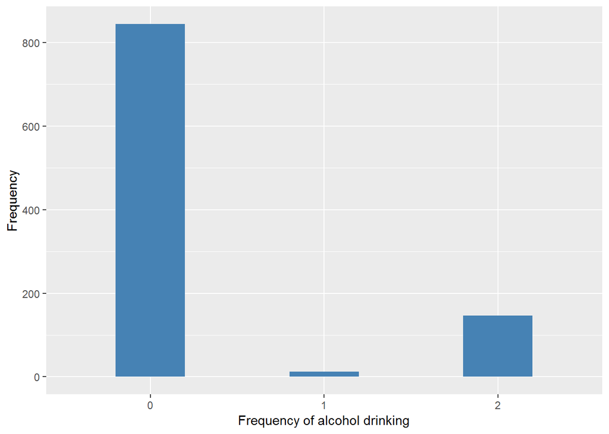

Past drinking

| Sample size | Missing values |
| --- | --- |
| 1002 | 0 |

Category

|  | 0 | 1 |
| --- | --- | --- |
| Frequency | 816.00 | 186.00 |
| Percentage | 81.44 | 18.56 |

Type of missing

|  | 991 | 992 | 993 | 994 | 995 | 996 | 997 | 998 | 999 | NA |
| --- | --- | --- | --- | --- | --- | --- | --- | --- | --- | --- |
| Frequency | 0 | 0 | 0 | 0 | 0 | 0 | 0 | 0 | 0 | 0 |
| Percentage | 0 | 0 | 0 | 0 | 0 | 0 | 0 | 0 | 0 | 0 |

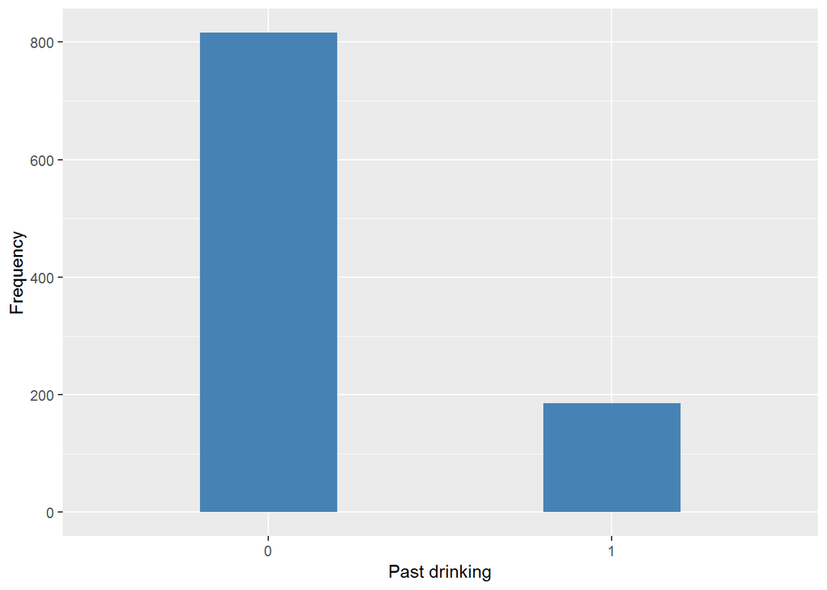

#### 2.4.1.4 Validation

### 2.4.2 Wave 2

#### 2.4.2.1 Study-specific variable description

| **Name** | `f_PALCPAST` |
| --- | --- |
| **Label** | `In the last week how much did you drink` `1 unit = a small glass of beer = a single measure of spirits = 1 glass of wine or sherry` `32 units = 1 bottle of spirits` |
| **Table name** | `1066-RuralChina-Followup` |
| **Categories** | `continuous` |
| **Missings** | `NA` |
| **Description** |  |

f_PALCPAST

| Sample size | Missing values |
| --- | --- |
| 711 | 2 |

Summary

| Min. | 1st Qu. | Median | Mean | 3rd Qu. | Max. | NA’s |
| --- | --- | --- | --- | --- | --- | --- |
| 0 | 0 | 0 | 4.144 | 0 | 224 | 2 |

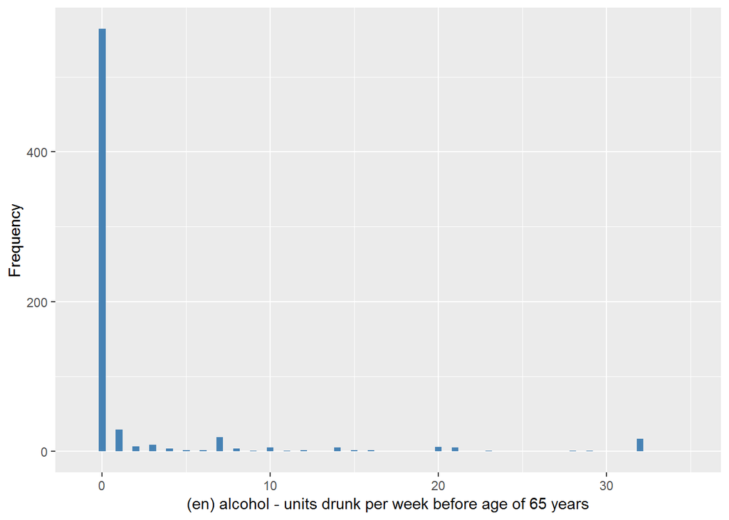

#### 2.4.2.2 Harmonisation algorithm

To compute `current_oh` from the study-specific variable it has to be recoded as follows:

- `f_PALCPAST == 0 into 0`
- `f_PALCPAST > 0 into 1`
- `NA into 999`

To compute `freq_oh` from the study-specific variable it has to be recoded as follows:

- `If f_PALCPAST=0 then 'drinking_frequency'=0`
- `if f_PALCPAST=1 or 2 then 'drinking_frequency'=1`
- `if f_PALCPAST>2 then 'drinking_frequency'=2`

To compute `past_oh` from the study-specific variable it has to be recoded as follows:

- `take from wave 1`

**R script:**

```r
t1066_ds_RCh_w2 <- tibble(id = t1066_RCh_w2$id)

t1066_ds_RCh_w2$freq_oh <- car::recode(t1066_RCh_w2$f_PALCPAST, "0 = 0; c(1,2) = 1; 3:hi = 2; NA = 999")
t1066_ds_RCh_w2$current_oh <- car::recode(t1066_ds_RCh_w2$freq_oh, "2 = 1")

t1066_RCh_w2 <- left_join(t1066_RCh_w2, t1066_ds_RCh_w1, by = "id")
t1066_ds_RCh_w2$past_oh <- t1066_RCh_w2$past_oh
```

#### 2.4.2.3 Statistics of the new harmonized variable

Current alcohol drinker

| Sample size | Missing values |
| --- | --- |
| 711 | 2 |

Category

|  | 0 | 1 |
| --- | --- | --- |
| Frequency | 564.00 | 145.00 |
| Percentage | 79.32 | 20.39 |

Type of missing

|  | 991 | 992 | 993 | 994 | 995 | 996 | 997 | 998 | 999 | NA |
| --- | --- | --- | --- | --- | --- | --- | --- | --- | --- | --- |
| Frequency | 0 | 0 | 0 | 0 | 0 | 0 | 0 | 0 | 2.00 | 0 |
| Percentage | 0 | 0 | 0 | 0 | 0 | 0 | 0 | 0 | 0.28 | 0 |

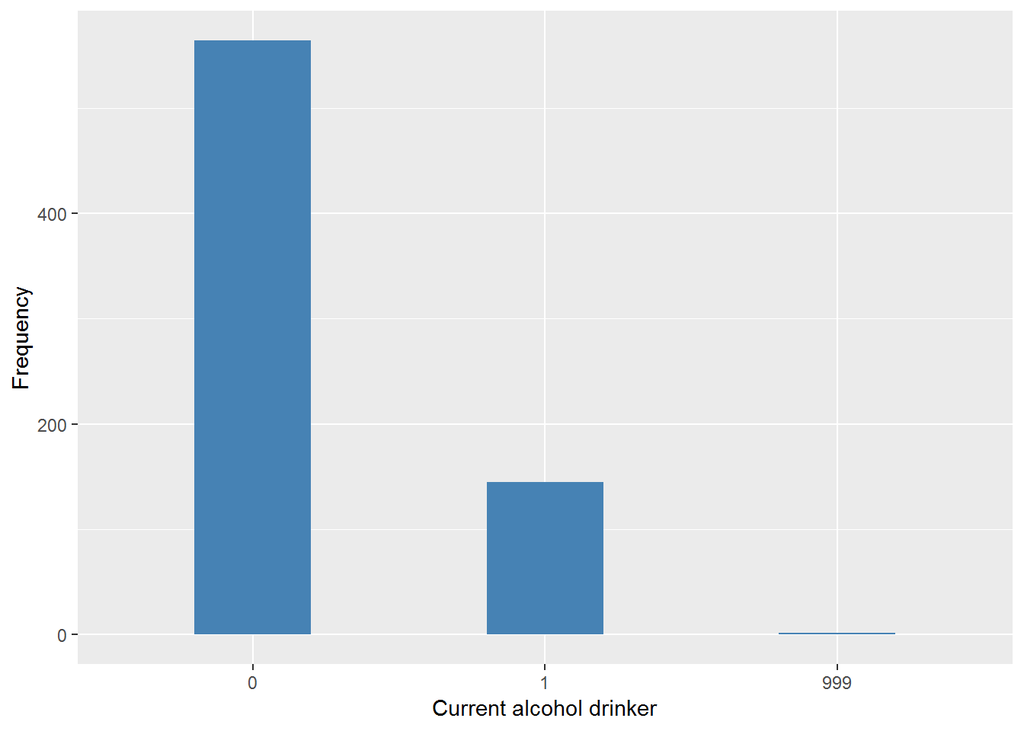

Frequency of alcohol drinking

| Sample size | Missing values |
| --- | --- |
| 711 | 2 |

Category

|  | 0 | 1 | 2 |
| --- | --- | --- | --- |
| Frequency | 564.00 | 36.00 | 109.00 |
| Percentage | 79.32 | 5.06 | 15.33 |

Type of missing

|  | 991 | 992 | 993 | 994 | 995 | 996 | 997 | 998 | 999 | NA |
| --- | --- | --- | --- | --- | --- | --- | --- | --- | --- | --- |
| Frequency | 0 | 0 | 0 | 0 | 0 | 0 | 0 | 0 | 2.00 | 0 |
| Percentage | 0 | 0 | 0 | 0 | 0 | 0 | 0 | 0 | 0.28 | 0 |

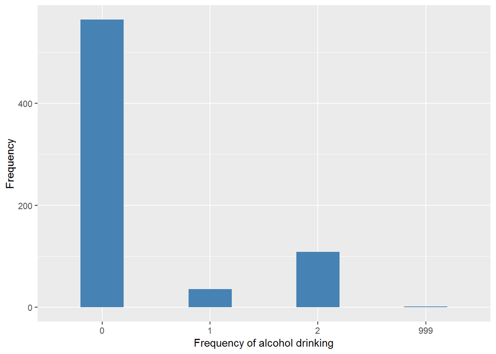

Past drinking

| Sample size | Missing values |
| --- | --- |
| 711 | 0 |

Category

|  | 0 | 1 |
| --- | --- | --- |
| Frequency | 572.00 | 139.00 |
| Percentage | 80.45 | 19.55 |

Type of missing

|  | 991 | 992 | 993 | 994 | 995 | 996 | 997 | 998 | 999 | NA |
| --- | --- | --- | --- | --- | --- | --- | --- | --- | --- | --- |
| Frequency | 0 | 0 | 0 | 0 | 0 | 0 | 0 | 0 | 0 | 0 |
| Percentage | 0 | 0 | 0 | 0 | 0 | 0 | 0 | 0 | 0 | 0 |

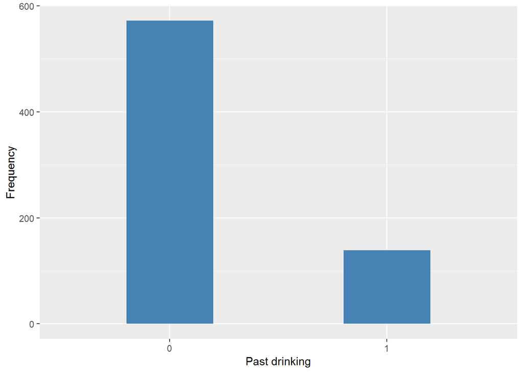